# test6

Before you turn this problem in, make sure everything runs as expected. First, **restart the kernel** (in the menubar, select Kernel$\rightarrow$Restart) and then **run all cells** (in the menubar, select Cell$\rightarrow$Run All).

Make sure you fill in any place that says `YOUR CODE HERE` or "YOUR ANSWER HERE", as well as your name and collaborators below:

```python
NAME = ""
COLLABORATORS = ""
```

### Dimensionality Reduction

`For Facial Recongition`

```python
import nose.tools as test_# For testing
import numpy as np
import matplotlib.pyplot as plt

from sklearn.model_selection import train_test_split
from sklearn.datasets import fetch_olivetti_faces
from sklearn.decomposition import PCA
from sklearn.svm import SVC
```

```python
# Useful in beautifying numpy arrays.
from IPython.display import HTML, display
import tabulate
def pp(a, show_head=True):
    '''
    args: show_head -> if True print only first 5 rows.
    return: None
    '''
    if a.ndim < 2:
        a = [a]
    if show_head:
        display(HTML(tabulate.tabulate(a[:5], tablefmt='html')))
        return
    display(HTML(tabulate.tabulate(a, tablefmt='html')))
```

Apple [FaceID](https://en.wikipedia.org/wiki/Face_ID) and Facebook DeepFace are two modern examples of [Facial Recoginition System](https://en.wikipedia.org/wiki/Facial_recognition_system).

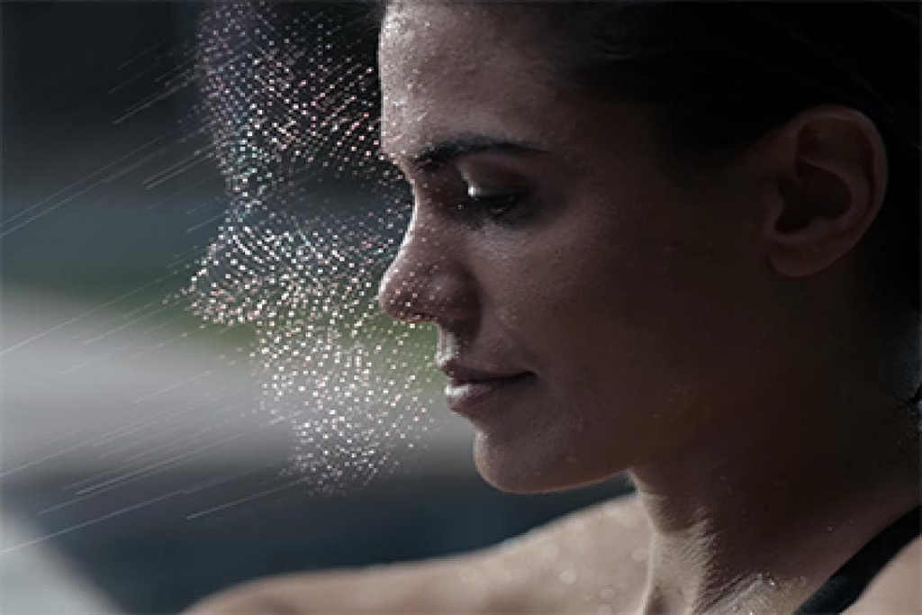

At present Deep Learning for Computer Vision (face recognition etc) has become the de-facto standard. For example, DeepFace is essentially a 9 layer Neural Network. While Deep Learning is something we'll cover in the last quarter of this course, we'll recognize faces here using `PCA`.

### Eigenface and PCA

`EigenFaces`: An [eigenface](https://en.wikipedia.org/wiki/Eigenface) is a set of eigenvectors in the context of facial recognition. For our purposes, simple assume that `principal components` (which explain most of the variance of data) we learned about in the tutorial on PCA are eigenfaces.

`Pros of Eigenfaces/PCA for Facial Recognition:`;

- Efficiency.
- As eigenface is primarily a dimension reduction method, relatively small set of data is needed for representation.
- Fairly invariant to large reductions in image sizing.

`Cons of Eigenfaces/PCA for Facial Recognition:`;

- It begins to fail considerably when the variations in train data and test data are a lot.

This is what Eigenfaces look like for greyscale images:

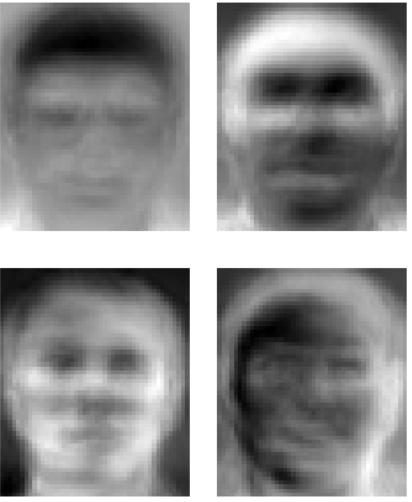

## Dataset

We'll use [The Olivetti faces dataset](https://scikit-learn.org/stable/modules/generated/sklearn.datasets.fetch_olivetti_faces.html#sklearn.datasets.fetch_olivetti_faces). This dataset contains a set of face images taken between April 1992 and April 1994 at AT&T Laboratories Cambridge. Familiarize yourself with this dataset by reading the [documentation](https://scikit-learn.org/stable/datasets/index.html#the-olivetti-faces-dataset).

### Question 1

Load the [The Olivetti faces dataset](https://scikit-learn.org/stable/modules/generated/sklearn.datasets.fetch_olivetti_faces.html#sklearn.datasets.fetch_olivetti_faces) from sklearn.

```python
def load_data(rns, _shuffle):
    '''
    Load the dataset

    rns -> int -> random state
    _shuffle -> bool -> whether to shuffle the dataset.

    return: object of type sklearn.utils.Bunch which is dict like.

    '''
    # YOUR CODE HERE
    raise NotImplementedError()
```

```python
olivetti_data_ = (load_data(5, True))
```

```python
test_.eq_(list(olivetti_data_.keys()), ['data', 'images', 'target', 'DESCR'])
```

```python
olivetti_data_dict = load_data(0, True)
```

Notice what each key is storing in olivetti_data_dict.

You've successfuly loaded the dataset of faces at this point. Currently, they are ndarrays which we humans can't make much sense of in terms of facial recognition. Let's show those images- visualize. Recall that you've already immplemented a similar function in test 5 called `display_image`. Here, we'll provide you its solution as well.

## Question 2

First, write a function which extract image(s) (ndarrays) from olivetti*data* given an index or a [slice](https://numpy.org/doc/stable/reference/arrays.indexing.html).

```python
def extract_images(data, idxs_tuple):
    '''
    Extract those images which are specified in idxs_tuple.


    args: data -> object of type sklearn.utils.Bunch which is dict like
          idxs_tuple -> of len 1 or 2. -> (a,) or (b, c)

    return: ndarray -> shape (n, 64, 64) where is total images extracted based on idxs_tuple


    For simplicity assume that idxs_tuple could be either of length 1 or length 2.
    If idxs_tuple is of length one, it's and index, if it's of
    length two, it's a slice.
    Negative slicing/indexing (e.g array[-1] returns last row) should also work.
    Which ideally shouldn't need any additional code.

    '''
    # YOUR CODE HERE
    raise NotImplementedError()
```

```python
test_.eq_(len(extract_images(olivetti_data_, (5,10))), 5)
test_.ok_ (np.isclose(extract_images(olivetti_data_, (5,))[:1], np.array([[0.3140496 , 0.29752067, 0.2768595 , 0.22727273, 0.19421488,
        0.16115703, 0.13636364, 0.12809917, 0.1694215 , 0.3264463 ,
        0.48347107, 0.5413223 , 0.57024795, 0.58677685, 0.58264464,
        0.57024795, 0.54545456, 0.5206612 , 0.46280992, 0.42975205,
        0.4090909 , 0.41322315, 0.3677686 , 0.33471075, 0.3140496 ,
        0.338843  , 0.36363637, 0.38842976, 0.38842976, 0.3966942 ,
        0.41735536, 0.4090909 , 0.42561984, 0.45867768, 0.47933885,
        0.49586776, 0.5041322 , 0.5       , 0.48347107, 0.47107437,
        0.47933885, 0.4876033 , 0.48347107, 0.49586776, 0.5       ,
        0.5       , 0.5       , 0.5082645 , 0.5289256 , 0.53305787,
        0.5413223 , 0.5371901 , 0.5289256 , 0.5123967 , 0.47933885,
        0.43801653, 0.39256197, 0.34710744, 0.29338843, 0.2768595 ,
        0.24793388, 0.21487603, 0.17768595, 0.16528925]])).all())
```

```python
# Extract images 16 images. Arbitray indexing.
images = extract_images(olivetti_data_, (10,26))
len(images)
```

### Question 3

Now, you'll display/plot the extracted images. Implement the function `display_all_images()` in which given $n^2$ images, display each of them on a $n\times n$ grid.

Solution of `display_image()` from previous test is provided which you must use/call in your implementation of `display_all_images()`.

Hint: [subplot](https://matplotlib.org/api/_as_gen/matplotlib.pyplot.subplot.html)

```python
# Modified Solution provided from test 5.
def display_image(image, _title):
    '''
    Display the image.
    args: image -> ndarray
          title -> string
    '''
    plt.axis('off')
    plt.title(_title)
    return plt.imshow(image, aspect='auto') # return value used in 'display_all_images()'
```

```python
def display_all_images(images):
    '''
    Display all images in a grid.
    args: images -> ndarray -> shape (n, 64, 64) where n is total images to display
          For simplicity, assume that n is a square number e.g. 4,9,16,..

    return: list -> A list of of matplotlib.image.AxesImage objects which is return value of
    `display_image()` already provided for you.
    '''
    list_of_Axes_objects = []
    # YOUR CODE HERE
    raise NotImplementedError()
    return list_of_Axes_objects

axes = display_all_images(images)
```

```python
axes = display_all_images(images)
```

```python
# All test cases are hidden
```

`Expected Output`

Your output should look like this (We did not specify any figure size arguments, so if your output contains images of smaller size, that's also fine. But it should be a 4x4 grid):

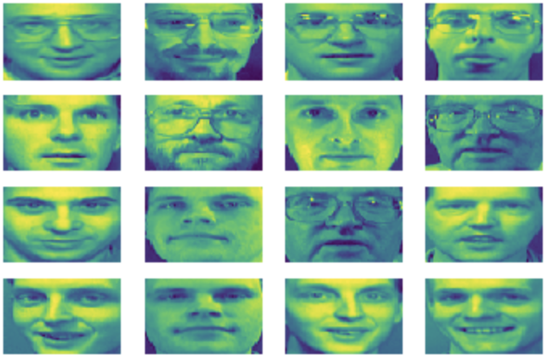

### Data To Train PCA

We'll train on rank 2 images (ndarray). Rank 3 ndarray images were suitable were displaying.

```
olivetti_data_.data == olivetti_data_.images.reshape(400, -1) # True
```

```python
# Helper functions which convert rank2 array to rank3 and vice versa.
make_rank2 = lambda rank3arr: rank3arr.reshape(400, -1)
make_showable_image = lambda rank2arr: rank2arr.reshape(-1,64,64) # make rank3
```

```python
rank2_data = olivetti_data_.data
print('Shape before (rank 2):')
print(rank2_data.shape)
showable_images = make_showable_image(rank2_data)
print('Shape After calling "make_showable_image" (rank 3):')
print(showable_images.shape)
```

```python
X = olivetti_data_.data
print(X.shape) # (400, 64*64)
y = olivetti_data_.target
```

### Train Test Split

```python
X_train, X_test, y_train, y_test = train_test_split(
    X, y, test_size=0.25, random_state=42)
```

```python
n_components = 150
```

### Question 4

Fit a PCA model on given data.

```python
def train_pca(_X_train, _n_components, _solver, _whiten):
    '''
    args: _X_train -> ndarray -> shape (n, k)
        _n_components -> int
        _solver -> string (Read documentation of PCA)
        _whiten -> bool -> (Read documentation of PCA

    return: an object of type sklearn.decomposition._pca.PCA
    '''
    # YOUR CODE HERE
    raise NotImplementedError()
```

```python
pca = train_pca(X_train, 150, 'randomized', True)
test_.eq_(pca.components_.shape, (150, 4096))
```

```python
pca = train_pca(X_train, 150, 'randomized', True)
```

### Question 5

Find out how much variance is explained by each eigenface (principal component).

```python
def var_explained_amount(_pca):
    '''
    pca -> object of type "sklearn.decomposition._pca.PCA"

    retrun ndarray of shape (n_components,)
    '''
    # YOUR CODE HERE
    raise NotImplementedError()
```

```python
test_.eq_(len(var_explained_amount(pca)), n_components)
```

```python
print('variance explained by each component:')
pp(var_explained_amount(pca))
```

### Question 6

Get Eigenfaces (principal components) given a pca model.

```python
def get_eigenfaces(_pca):
    '''
    args: pca -> object of type "sklearn.decomposition._pca.PCA"

    retrun ndarray of shape (n_components,64*64)
    '''
    # YOUR CODE HERE
    raise NotImplementedError()
```

```python
test_.eq_(get_eigenfaces(pca).shape, (150, 4096))
```

### Question 7

Project the input data on the eigenfaces orthonormal basis. In other words, simply transform the data using pca.

```python
def _transform(_pca, data):
    '''
    args: pca -> object of type "sklearn.decomposition._pca.PCA"
    return: ndarray (n, ncomponents) where n is len(data)
    '''
    # YOUR CODE HERE
    raise NotImplementedError()
```

```python
X_train_pca = _transform(pca, X_train)
test_.eq_(len(X_train_pca), 300)
```

```python
X_train_pca = _transform(pca, X_train)
X_test_pca = _transform(pca, X_test)
```

### Question 8

Let's visualize how our eigenfaces look like. Use the same function `display_all_images()` to display eigenfaces. Here, you'll call the functions you've defined so far i.e. display_all_images, get_eigenfaces, and make_showable_image (whose solution we provided)- Not necessarily in this order. get_eigenfaces will give you all the eigen faces, you need to display only first n (function argument) of them.

```python
def display_eigenfaces(_pca, n):
    '''
    Display/Plot first n eigenfaces you extract using PCA.

    args: pca -> object of type "sklearn.decomposition._pca.PCA"
          n -> int
    return: Exactly what display_all_images returns i.e. list -> A list
                                of of matplotlib.image.AxesImage objects

    '''
    # YOUR CODE HERE
    raise NotImplementedError()
```

```python
ax = display_eigenfaces(pca, 25)
```

```python
axes = display_eigenfaces(pca, 16)
test_.eq_(len(axes), (16))
test_.eq_((axes[0].get_array().shape), (64, 64))
```

### Expected Eigenfaces you should see for n = 25.

Your output should look like this (We did not specify any figure size arguments, so if your output contains images of smaller size, that's also fine. But it should be a 5x5 grid):

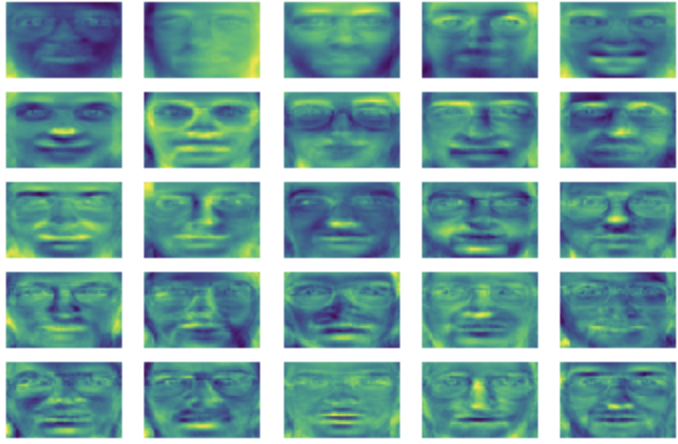

`Observing the eigenfaces, it makes sense that these principal components (eigenfaces) indeed explain most of the variance of images, and using only these we can make pretty good predictions with a classifier.`

Train a support vector classifier on transformed X_train (which has dimensionality reduced to `n_eigenfaces`). We'll do this for you. No need to write any code. But make sure you understand what's happening.

```python
svc_clf = SVC(kernel='rbf', class_weight='balanced', C=1000, gamma=0.005)
# train a SVC classifier.
svc_clf = svc_clf.fit(X_train_pca, y_train)
```

```python
svc_clf
```

```python
svc_clf.score(X_test_pca, y_test)
```

Now given a image this classifier can recognize whose face is that. Try prediction.